# UHG_Healthcare_Insurance

## 1. Business Problem Statement

United Health Group (UHG), a major health insurance provider, seeks to enhance its risk management through advanced data analytics. Given the industry's complexities, understanding and managing the associated risk and cost of each insurance plan is critical. The objective of this interview challenge is to use UHG's provided data to construct a predictive risk model, enhancing UHG's decision-making and potentially leading to more personalized insurance solutions.

```python
from google.colab import drive
drive.mount('/content/drive')
```

## 2. Dataset Description

**Table 1: `PlanData`**

The PlanData table contains details about various insurance plans that United Health Group offers.

| Column Name | Description |
| --- | --- |
| `plan_id` | Unique identifier for each insurance plan |
| `plan_name` | Name of the insurance plan |
| `plan_type` | Type of the insurance plan (e.g., HMO, PPO, EPO, POS) |
| `plan_premium` | The premium price of the insurance plan |
| `plan_deductible` | The deductible cost for the insurance plan |
| `plan_oop_max` | Out-of-pocket maximum/limit for the insurance plan |

**Table 2: `UserData`**

The UserData table has demographic information about the insured users.

| Column Name | Description |
| --- | --- |
| `user_id` | Unique identifier for each user |
| `age` | Age of the user |
| `gender` | Gender of the user |
| `location` | Residential location of the user |
| `plan_id` | Unique identifier of the plan user is subscribed to |
| `chronic_disease` | Indicates if user has a chronic disease |

**Table 3: `ClaimData`**

The ClaimData table includes details about insurance claims made by users.

| Column Name | Description |
| --- | --- |
| `claim_id` | Unique identifier for each claim |
| `user_id` | Unique identifier of the user who made the claim |
| `plan_id` | Unique identifier of the plan under which claim is made |
| `claim_date` | Date when the claim was made |
| `claim_amount` | Amount of the claim |
| `claim_reason` | Reason for the claim (e.g., hospitalization, prescription, etc.) |
| `claim_status` | Status of the claim (paid, rejected, etc.) |

## Load Data

```python
import pandas as pd
# from google.colab import drive

# Mount Google Drive
# drive.mount('/content/drive')

file_path1 = 'https://storage.googleapis.com/datalynn-datasets/interview-challenge/pharmacetutical-and-biotechnology/UHG_Healthcare_Insurance/UserData.csv'
file_path2 = 'https://storage.googleapis.com/datalynn-datasets/interview-challenge/pharmacetutical-and-biotechnology/UHG_Healthcare_Insurance/PlanData.csv'
file_path3 = 'https://storage.googleapis.com/datalynn-datasets/interview-challenge/pharmacetutical-and-biotechnology/UHG_Healthcare_Insurance/ClaimData.csv'

UserData = pd.read_csv(file_path1)
PlanData = pd.read_csv(file_path2)
ClaimData = pd.read_csv(file_path3)
```

## 3. Questions

### 3.1. Identifying Risk Categories in Insurance Plans (Python)

In the context of health insurance, the term "risk" often refers to the likelihood or probability that an insured individual will make a claim, as well as the probable cost of those claims. Risk is often influenced by a variety of factors, such as the individual's age, health conditions, lifestyle habits, and the specifics of their insurance plan.

For instance, older individuals or those with chronic diseases are typically at a higher risk of making claims due to health issues. Similarly, certain types of plans (like those with lower deductibles or out-of-pocket maximums) may also be associated with a higher risk, as individuals are more likely to make claims when they know they'll have to pay less out-of-pocket.

With these considerations in mind, your task is to use the historical data available in 'PlanData', 'UserData', and 'ClaimData' tables to **classify our insurance plans into risk categories**. What criteria would you use for this classification? Please explain the process and results of your classification strategy.

#### **Answer 3.1.**

```python
# Import library
from sklearn.cluster import KMeans
from sklearn.preprocessing import StandardScaler

# Data is already loaded into DataFrames

# Merge data into a single DataFrame
merged_data = pd.merge(UserData, PlanData, on='plan_id')
merged_data = pd.merge(merged_data, ClaimData, on=['user_id', 'plan_id'])

# Feature Engineering
features = merged_data.groupby('plan_id').agg({
    'age': 'mean',  # average age
    'chronic_disease': 'mean',  # proportion of users with chronic disease
    'claim_amount': 'sum',  # total claim amount
    'claim_id': 'count'  # number of claims (claim frequency)
})

# Standardize features
scaler = StandardScaler()
scaled_features = scaler.fit_transform(features)

# Use KMeans to classify plans into 3 risk categories
kmeans = KMeans(n_clusters=3, random_state=0)
kmeans.fit(scaled_features)

# Assign the risk category to each plan
features['risk_category'] = kmeans.labels_

# Print the results
print(features)
```

```
               age  chronic_disease  claim_amount  claim_id  risk_category
plan_id
0        32.000000         0.000000   5151.626888         2              0
1        27.000000         0.000000   1899.029691         1              0
2        30.333333         0.000000   3428.176651         3              0
6        55.333333         0.333333   3263.338211         3              0
9        56.000000         0.000000    951.720476         1              0
...            ...              ...           ...       ...            ...
992      56.000000         1.000000   2740.855122         2              2
993      51.000000         1.000000   1263.855166         1              2
994      32.000000         0.000000   2457.899176         1              0
996      25.500000         0.000000   1946.276093         2              0
997      55.000000         0.000000   5040.466006         2              0

[471 rows x 5 columns]
```

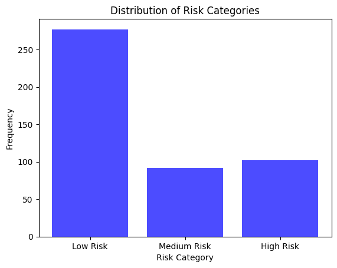

```python
# Adding the 'risk_category' to the PlanData DataFrame
PlanData = pd.merge(PlanData, features['risk_category'], on='plan_id', how='left')

# Import library
import matplotlib.pyplot as plt

# Plot the distribution of risk categories
plt.hist(PlanData['risk_category'], bins=range(4), align='left', rwidth=0.8, color='blue', alpha=0.7)
plt.xticks(range(3), ['Low Risk', 'Medium Risk', 'High Risk'])
plt.title('Distribution of Risk Categories')
plt.xlabel('Risk Category')
plt.ylabel('Frequency')
plt.show()
```

### 3.2. Data Transformation and Target Creation (SQL)

The target variable for our predictive model is 'total_claim_amount', which is the sum of all claim amounts made by a user under a specific insurance plan. Can you write an SQL query to create this target variable from the 'ClaimData' table? Explain your approach.

#### **Answer 3.2.**

```python
# Create a connection to an SQLite database in memory
conn = sqlite3.connect(':memory:')

# Write the dataframes to the SQLite database
PlanData.to_sql('PlanData', conn, if_exists='replace', index=False)
UserData.to_sql('UserData', conn, if_exists='replace', index=False)
ClaimData.to_sql('ClaimData', conn, if_exists='replace', index=False)

# Perform the SQL query and read it directly into a DataFrame
total_claim_amount_df = pd.read_sql_query("""
    SELECT user_id, plan_id, SUM(claim_amount) AS total_claim_amount
    FROM ClaimData
    GROUP BY user_id, plan_id
""", conn)

# Add the total_claim_amount to the ClaimData DataFrame
ClaimData = pd.merge(ClaimData, total_claim_amount_df, on=['user_id', 'plan_id'], how='left')

# Close the SQLite connection
conn.close()
```

```python
ClaimData.head()
```

|  | claim_id | user_id | plan_id | claim_date | claim_amount | claim_reason | claim_status | total_claim_amount |
| --- | --- | --- | --- | --- | --- | --- | --- | --- |
| 0 | 0 | 726 | 860 | 2021-01-01 | 1725.082900 | prescription | paid | 1725.082900 |
| 1 | 1 | 763 | 532 | 2021-01-02 | 1717.453165 | prescription | paid | 7739.464220 |
| 2 | 2 | 620 | 211 | 2021-01-03 | 1341.077971 | prescription | paid | 1341.077971 |
| 3 | 3 | 626 | 775 | 2021-01-04 | 1833.963418 | prescription | rejected | 5423.141570 |
| 4 | 4 | 180 | 60 | 2021-01-05 | 2829.865477 | hospitalization | paid | 3860.811890 |

### 3.3. Feature Selection (Python)

Based on risk definition and the new target variable, what features from 'PlanData', 'UserData', and 'ClaimData' tables would you choose to include in the predictive model? Discuss the reasons behind your choices.

#### **Answer 3.3.**

```python
# Merging all tables into one dataframe
df = pd.merge(UserData, PlanData, on='plan_id')
df = pd.merge(df, ClaimData, on=['user_id', 'plan_id'])

# Transform categorical variables into dummy variables
df = pd.get_dummies(df, drop_first=True)

# Drop id columns
df = df.drop(columns=['plan_id', 'user_id', 'claim_id'])

# Feature engineering on 'claim_date'
df['claim_year'] = pd.DatetimeIndex(df['claim_date']).year
df = df.drop(columns='claim_date')

# One-hot encoding for categorical features
df = pd.get_dummies(df, drop_first=True)

# Correlation matrix
corr_matrix = df.corr()

# Select upper triangle of correlation matrix
upper = corr_matrix.where(np.triu(np.ones(corr_matrix.shape), k=1).astype(np.bool))

# Identify columns to drop based on threshold
to_drop = [column for column in upper.columns if any(upper[column].abs() > 0.8)]

# Drop highly correlated features
df = df.drop(df[to_drop], axis=1)

df.head()
```

|  | age | chronic_disease | plan_premium | plan_deductible | plan_oop_max | risk_category | claim_amount | total_claim_amount | gender_M | location_Alexandrastad | ... | location_West Williamview | location_Williamsfurt | location_Williamsmouth | location_Youngview | location_Zacharyhaven | plan_type_HMO | plan_type_POS | plan_type_PPO | claim_status_rejected | claim_year |
| --- | --- | --- | --- | --- | --- | --- | --- | --- | --- | --- | --- | --- | --- | --- | --- | --- | --- | --- | --- | --- | --- |
| 0 | 38 | 0 | 557.522748 | 792.844527 | 5216.295913 | 0.0 | 3568.959528 | 4269.026931 | 0 | 0 | ... | 0 | 0 | 0 | 0 | 0 | 0 | 0 | 1 | 0 | 2021 |
| 1 | 38 | 0 | 557.522748 | 792.844527 | 5216.295913 | 0.0 | 465.275286 | 4269.026931 | 0 | 0 | ... | 0 | 0 | 0 | 0 | 0 | 0 | 0 | 1 | 0 | 2022 |
| 2 | 38 | 0 | 557.522748 | 792.844527 | 5216.295913 | 0.0 | 234.792117 | 4269.026931 | 0 | 0 | ... | 0 | 0 | 0 | 0 | 0 | 0 | 0 | 1 | 0 | 2023 |
| 3 | 42 | 0 | 297.287643 | 763.540012 | 3757.516749 | 1.0 | 522.519951 | 5017.808142 | 1 | 0 | ... | 0 | 0 | 0 | 0 | 0 | 0 | 0 | 0 | 1 | 2022 |
| 4 | 42 | 0 | 297.287643 | 763.540012 | 3757.516749 | 1.0 | 1583.518942 | 5017.808142 | 1 | 0 | ... | 0 | 0 | 0 | 0 | 0 | 0 | 0 | 0 | 1 | 2022 |

5 rows × 632 columns

```python
# Transform categorical variables into dummy variables
from sklearn.preprocessing import LabelEncoder

# Label encoding for ordinal categorical variables
labelencoder = LabelEncoder()

# Merging all tables into one dataframe
df = pd.merge(UserData, PlanData, on='plan_id')
df = pd.merge(df, ClaimData, on=['user_id', 'plan_id'])

# Select categorical columns to apply label encoding
categorical_cols = ['gender', 'location', 'plan_type', 'claim_reason', 'claim_status']

# Apply label encoding to each column
df[categorical_cols] = df[categorical_cols].apply(lambda col: labelencoder.fit_transform(col))

# Drop id columns
df = df.drop(columns=['plan_id', 'user_id', 'claim_id'])

# Feature engineering on 'claim_date'
df['claim_year'] = pd.DatetimeIndex(df['claim_date']).year
df = df.drop(columns='claim_date')

# Correlation matrix
corr_matrix = df.corr()

# Select upper triangle of correlation matrix
upper = corr_matrix.where(np.triu(np.ones(corr_matrix.shape), k=1).astype(np.bool))

# Identify columns to drop based on threshold
to_drop = [column for column in upper.columns if any(upper[column].abs() > 0.8)]

# Drop highly correlated features
df = df.drop(df[to_drop], axis=1)

df.head()
```

|  | age | gender | location | chronic_disease | plan_type | plan_premium | plan_deductible | plan_oop_max | risk_category | claim_amount | claim_status | total_claim_amount | claim_year |
| --- | --- | --- | --- | --- | --- | --- | --- | --- | --- | --- | --- | --- | --- |
| 0 | 38 | 0 | 277 | 0 | 3 | 557.522748 | 792.844527 | 5216.295913 | 0.0 | 3568.959528 | 0 | 4269.026931 | 2021 |
| 1 | 38 | 0 | 277 | 0 | 3 | 557.522748 | 792.844527 | 5216.295913 | 0.0 | 465.275286 | 0 | 4269.026931 | 2022 |
| 2 | 38 | 0 | 277 | 0 | 3 | 557.522748 | 792.844527 | 5216.295913 | 0.0 | 234.792117 | 0 | 4269.026931 | 2023 |
| 3 | 42 | 1 | 309 | 0 | 0 | 297.287643 | 763.540012 | 3757.516749 | 1.0 | 522.519951 | 1 | 5017.808142 | 2022 |
| 4 | 42 | 1 | 309 | 0 | 0 | 297.287643 | 763.540012 | 3757.516749 | 1.0 | 1583.518942 | 1 | 5017.808142 | 2022 |

```python
# Splitting features and target variable
X = df.drop('total_claim_amount', axis=1)
y = df['total_claim_amount']

# Correlation analysis
correlation = X.corrwith(y)
print(correlation.sort_values(ascending=False))

# Random Forest for feature importance
from sklearn.ensemble import RandomForestRegressor

rf = RandomForestRegressor(random_state=42)
rf.fit(X, y)

# Get feature importance
importance = pd.DataFrame({
    'Feature': X.columns,
    'Importance': rf.feature_importances_
})

print(importance.sort_values(by='Importance', ascending=False))
```

```
claim_amount       0.480905
risk_category      0.215231
plan_premium       0.120554
chronic_disease    0.071795
plan_type          0.061000
gender             0.049524
claim_year         0.044101
location           0.013392
age               -0.004137
claim_status      -0.020498
plan_oop_max      -0.034267
plan_deductible   -0.069435
dtype: float64
            Feature  Importance
9      claim_amount    0.305614
8     risk_category    0.185769
5      plan_premium    0.118522
7      plan_oop_max    0.092245
2          location    0.087361
0               age    0.085087
6   plan_deductible    0.072316
4         plan_type    0.020487
1            gender    0.010652
11       claim_year    0.009904
3   chronic_disease    0.007766
10     claim_status    0.004277
```

### 3.4. Model Selection, Optimization, and Training (Python)

Considering the features and target variable you've selected, propose a suitable predictive model to estimate the 'total_claim_amount'. Please provide your Python code for model training and hyperparameter optimization. Discuss your rationale behind choosing this specific model and your approach for hyperparameter tuning.

#### **Answer 3.4.**

```python
from sklearn.model_selection import train_test_split
from sklearn.ensemble import GradientBoostingRegressor
from sklearn.model_selection import RandomizedSearchCV

# Select target variable
y = df['total_claim_amount']
X = df.drop('total_claim_amount', axis=1)

# Split dataset into training set and test set
X_train, X_test, y_train, y_test = train_test_split(X, y, test_size=0.2, random_state=42)

# Initialize Gradient Boosting Regressor
gb = GradientBoostingRegressor()

# Define hyperparameters grid
param_dist = {
    'n_estimators': [50, 100, 200, 300, 500],
    'learning_rate': [0.01, 0.05, 0.1, 0.2],
    'max_depth': [2, 3, 5, 10],
    'subsample': [0.5, 0.7, 1.0],
    'max_features': ['auto', 'sqrt', 'log2']
}

# Use Randomized Search CV for hyperparameter tuning
random_search = RandomizedSearchCV(gb, param_distributions=param_dist, n_iter=20, scoring='neg_mean_squared_error', n_jobs=-1, cv=5, random_state=42)
random_search.fit(X_train, y_train)

# Train model with best parameters
gb_best = GradientBoostingRegressor(n_estimators=random_search.best_params_['n_estimators'],
                                    learning_rate=random_search.best_params_['learning_rate'],
                                    max_depth=random_search.best_params_['max_depth'],
                                    subsample=random_search.best_params_['subsample'],
                                    max_features=random_search.best_params_['max_features'])

gb_best.fit(X_train, y_train)
```

```
GradientBoostingRegressor(learning_rate=0.05, max_depth=10, max_features='sqrt',
                          n_estimators=300, subsample=0.7)
```

### 3.5. Model Evaluation (Python)

After training and optimizing your model, how would you assess its performance? Please provide your Python code to evaluate your model using appropriate metrics. Considering our business problem, explain why you chose these metrics and how they reflect the model's capability to predict 'total_claim_amount'.

#### **Answer 3.5.**

```python
# from sklearn.metrics import mean_squared_error, mean_absolute_error, r2_score

# # Make predictions on the test set
# y_pred = gb_best.predict(X_test)

# # Calculate evaluation metrics
# mse = mean_squared_error(y_test, y_pred)
# mae = mean_absolute_error(y_test, y_pred)
# r2 = r2_score(y_test, y_pred)

# print("Mean Squared Error (MSE): ", mse)
# print("Mean Absolute Error (MAE): ", mae)
# print("R-squared (R2): ", r2)
```

```python
from sklearn.metrics import r2_score, explained_variance_score

# Make predictions on the test set
y_pred = gb_best.predict(X_test)

# Calculate R-squared
r2 = r2_score(y_test, y_pred)

# Calculate adjusted R-squared
n = X.shape[0]  # Number of samples
p = X.shape[1]  # Number of predictors
adjusted_r2 = 1 - (1 - r2) * ((n - 1) / (n - p - 1))

# Calculate explained variance score
explained_var_score = explained_variance_score(y_test, y_pred)

print("R-squared (R2): ", r2)
print("Adjusted R-squared: ", adjusted_r2)
print("Explained Variance Score: ", explained_var_score)
```

```
R-squared (R2):  0.6676509069877371
Adjusted R-squared:  0.663610188531661
Explained Variance Score:  0.6696371779457014
```